# Replication Assignment

Isabel Novick

12/10/2021

[figure not shown]

## Introduction

The study containing the analyses I am attempting to replicate is “Extending the ecology of fear: Parasite-mediated sexual selection drives host response to parasites” by Horn et al, 2020. This study investigates non-consumptive effects of parasites (using ectoparasite Macrocheles subbadius) on potential hosts (Drosophila nigrospiracula). The authors use metabolic rate (MR) of host flies as a proxy for perceived risk of mite infection, recording the rate of CO2 production. They test two mutually exclusive hypotheses: either uneven costs of infection result in adaptions for stronger metabolic responses to mite exposure, or uneven risks of infection result in adaptions for stronger metabolic responses to mite exposure. Male flies will have higher cost of being parasitized due to their lower body mass compared to female flies. Virgin female flies will have a higher cost of being parasitized compared to mated females. These differences also affect infection risk, as mites preferentially infect female flies over males, and mated females over virgin females. The dataset used in this study recorded data in the following categories: individual code, respirometry chamber, sex, mass, CO2 production in ml/min, VCOsd, age, activity in voltage, mite infection, and batch. Datasets were split up not only by sex (male vs. female, mated vs. virgin females) but also by exposure to mites. In these analyses, “exposure” denotes being exposed to the parasitic mite, and “unexposed” or “at rest” are used interchangeably to mean having no contact with mites. Additionally, not all of these variables are investigated in my replication analysis. The tests performed in this study are age-matched and pair-wise choice tests, binomial tests, linear mixed effects models using the lmer function, generalized linear mixed effects models using the glmer function, and backwards model selection. Additionally, after performing an lmer test, the anova function was used to compare models, and the Wald t-statistic test was used for comparing glmer models as they are in a Gamma distribution. The study also uses a Shapiro-Wilk test on the residuals of models for normality. One last, very important note to make before beginning the analyses: I was able to get in contact with Collin Horn, the PhD candidate responsible for this paper (first author, so of course not completely responsible). He was an incredibly helpful and lovely man who sent me pages of his workflow for this project. Those documents can be found in this repo as well. He helped me through much of the glmer stuff, as well as some of the lmer stuff, and gave lots of helpful information about any discrepancies in the data. This whole replication analysis would have been much messier and would not been nearly as thorough if not for this guy’s help. Thank you, Collin! This was a really cool study and I enjoyed trying my best to replicate it!

## Analyses

### The analyses that I will be replicating are as follows:

### Descriptive statistical analysis:

Taking average weight and standard error of exposed male and female flies.

### Inferential statistical analysis:

Examining predictive variables of metabolic rate for unexposed male and female flies using lmer. This allows us to see which variables were significant predictors of metabolic rate, such as sex or mass. Model comparison was carried out with the anova function (test=χ2) for lmer models. The authors and I did lmer tests on the unexposed group, and then ran anovas to compare those models. I only compared variables of unexposed flies using the lmer function to see which variables are good predictors.

### Other analysis:

Examining predictive variables of metabolic rate for exposed male and female flies using glmer. The authors and I used the glmer function on the exposed group, due to its Gamma distribution, to look for predictive variables of MR. Model comparison was carried out with the Wald t-statistic for glmer models. For both lmer and glmer analyses, mass and sex were separated to avoid colinearity, as there is sexual dimorphism and female flies are larger.

### Other OTHER analysis:

Shapiro-Wilk test of normality. This is done on one lmer model and one glmer model

### SUPER OTHER other analysis:

Akaike Information Criterion (AIC) to compare prediction error between models and to establish which model (sex or mass) uses a more effective predictive variable.

### Other figure:

I also replicated a histogram of metabolic rate of male and female flies at rest. This histogram was not included in the actual paper, but was included in the supplementary materials that were shared with me.

## Step 1. Reading the data into R:

The data was available on Dryad as an .xlsx with 4 distinct tabs, holding different sets of data. I converted each tab to a .csv format, so now I have 4 different .csv files. Eventually I ended up splitting these further into more .csv files, containing each variable separately to help with analysis. These original files are respirometry data for male and female flies at rest, respirometry data for males and females exposed to mites, respirometry data for mated and virgin females at rest, and respirometry data for mated and virgin females exposed to mites. I have assigned each of them a name.

Loading in respirometry data for male and female flies at rest:

```r
mf_rest <- read.csv("Respirometry_data_male_and_female_at_rest.csv", header = TRUE, stringsAsFactors = FALSE)
head(mf_rest)
```

```
##   Code chamber Sex Mass CO2.prod.uL.min    VCOsd Age     Act batch
## 1   F1       1   F 2.63          0.1040 5.45e-06  20 0.08870   One
## 2   F2       3   F 2.31          0.1060 7.59e-06  20 0.00638   One
## 3   F3       5   F 2.52          0.0470 2.68e-06  20 0.00663   One
## 4   F4       7   F 2.32          0.0664 3.44e-06  20 0.00341   One
## 5   F5       9   F 2.68          0.0700 1.21e-05  20 0.04590   One
## 6   F6      11   F 2.66          0.0445 4.80e-06  20 0.05570   One
```

Loading in respirometry data for males and females exposed to mites:

```r
mf_exposed <- read.csv("Respirometry_data_male_and_female_exposed_to_mite.csv", header = TRUE, stringsAsFactors = FALSE)
head(mf_exposed)
```

```
##   Code chamber Sex Mass CO2.prod.uL.min Age    Act mites batch
## 1   F1       2   F 1.87          0.0586  21 0.3320     0     i
## 2   F2       4   F 2.19          0.0635  21 0.1320     0     i
## 3   F3       6   F 2.31          0.0337  21 0.0605     0     i
## 4   F4       8   F 2.05          0.0387  21 0.0731     0     i
## 5   F5      10   F 2.97          0.0430  21 0.0304     0     i
## 6   F6      12   F 2.28          0.0526  21 0.1130     0     i
```

Loading in respirometry data for mated and virgin females at rest:

```r
fem_rest <- read.csv("Respirometry_data_mated_and_virgin_females_rest.csv", header = TRUE, stringsAsFactors = FALSE)
head(fem_rest)
```

```
##   Fly.ID Replicate.block Date age Chamber Status CO2.prod.uL.min     Act Mass
## 1     V1               i dayA  19       1      V          0.0648 0.00753 2.17
## 2     V2               i dayA  19       3      V          0.0419 0.00282 2.26
## 3     V3               i dayA  19       5      V          0.0102 0.01340 2.31
## 4     V4               i dayA  19       7      V          0.0205 0.04650 3.11
## 5     V5               i dayA  19       9      V          0.0240 0.01170 2.82
## 6     V6               i dayA  19      11      V          0.0572 0.04550 2.25
##   Comments  X
## 1          NA
## 2          NA
## 3          NA
## 4          NA
## 5          NA
## 6          NA
```

Loading in respirometry data for mated and virgin females exposed to mites:

```r
fem_exposed <- read.csv("Respirometry_data_mated_and_virgin_exposed.csv", header = TRUE, stringsAsFactors = FALSE)
head(fem_exposed)
```

```
##   Code Replicate.block Chamber Status CO2.prod.uL.min  Act Mass Age Date
## 1   v1               i       1      v          0.1160 0.55 4.02  11 dayA
## 2   v2               i       3      v          0.0826 0.25 2.89  11 dayA
## 3   v3               i       5      v          0.0984 0.40 3.01  11 dayA
## 4   v4               i       7      v          0.0499 0.15 3.74  11 dayA
## 5   v5               i       9      v          0.0388 0.24 3.09  11 dayA
## 6   v6               i      11      v          0.0678 0.11 2.81  11 dayA
```

## Step 2

Load packages (or install them if I don’t have them yet):

```r
library(ggplot2)
library(stats)
library(lme4)
library(dplyr)
install.packages("plotrix")
```

[output not shown]

```r
library(plotrix)
install.packages("lmerTest")
```

[output not shown]

```r
library(lmerTest)
install.packages("aod")
```

[output not shown]

```r
library(aod)
```

## Step 3. Descriptive statistical analysis: Taking the average weight of exposed male and female flies.

From section 3.2.1 in results: Female flies in the exposed experiment on average had 24% higher masses than male flies, 2.48 ± 0.06 mg and 1.95 ± 0.03 mg respectively.

```r
summary(mf_exposed) #Use summary to get an idea of the data
```

```
##      Code              chamber         Sex                 Mass
##  Length:56          Min.   : 1.0   Length:56          Min.   :1.650
##  Class :character   1st Qu.: 4.0   Class :character   1st Qu.:1.907
##  Mode  :character   Median : 7.5   Mode  :character   Median :2.100
##                     Mean   : 7.5                      Mean   :2.213
##                     3rd Qu.:11.0                      3rd Qu.:2.455
##                     Max.   :14.0                      Max.   :2.970
##  CO2.prod.uL.min        Age            Act              mites
##  Min.   :0.03100   Min.   :11.0   Min.   :0.00360   Min.   :0.00000
##  1st Qu.:0.05267   1st Qu.:14.0   1st Qu.:0.05945   1st Qu.:0.00000
##  Median :0.06385   Median :15.0   Median :0.09045   Median :0.00000
##  Mean   :0.07291   Mean   :15.5   Mean   :0.12175   Mean   :0.03571
##  3rd Qu.:0.07860   3rd Qu.:16.5   3rd Qu.:0.14200   3rd Qu.:0.00000
##  Max.   :0.24900   Max.   :21.0   Max.   :1.02000   Max.   :1.00000
##     batch
##  Length:56
##  Class :character
##  Mode  :character
##
##
##
```

```r
male_exposed <- mf_exposed %>% filter(Sex == "M")
male_exposed
```

```
##    Code chamber Sex Mass CO2.prod.uL.min Age    Act mites batch
## 1    M1       1   M 1.84          0.1940  21 1.0200     0     i
## 2    M2       3   M 1.65          0.1040  21 0.0600     0     i
## 3    M3       5   M 1.83          0.0671  21 0.0587     0     i
## 4    M4       7   M 1.89          0.0452  21 0.1090     0     i
## 5    M5       9   M 1.79          0.0632  21 0.0209     1     i
## 6    M6      11   M 1.74          0.0381  21 0.0947     0     i
## 7    M7      13   M 1.92          0.0491  21 0.0642     1     i
## 8    M8       2   M 1.80          0.0510  11 0.0893     0    ii
## 9    M9       4   M 1.87          0.0619  11 0.2680     0    ii
## 10  M10       6   M 1.94          0.0399  11 0.0418     0    ii
## 11  M11       8   M 2.00          0.0546  11 0.0556     0    ii
## 12  M12      10   M 1.89          0.0635  11 0.0721     0    ii
## 13  M13      12   M 1.99          0.0609  11 0.0233     0    ii
## 14  M14      14   M 1.67          0.0629  11 0.0579     0    ii
## 15  M15       1   M 1.96          0.1010  15 0.1870     0   iii
## 16  M16       3   M 1.78          0.0642  15 0.1640     0   iii
## 17  M17       5   M 1.92          0.0527  15 0.0953     0   iii
## 18  M18       7   M 1.87          0.0469  15 0.0821     0   iii
## 19  M19       9   M 2.16          0.0665  15 0.0648     0   iii
## 20  M20      11   M 1.90          0.0512  15 0.0036     0   iii
## 21  M21      13   M 2.21          0.0545  15 0.2260     0   iii
## 22  M22       2   M 2.11          0.1460  15 0.1560     0    iv
## 23  M23       4   M 2.25          0.1140  15 0.0199     0    iv
## 24  M24       6   M 2.01          0.1160  15 0.2680     0    iv
## 25  M25       8   M 2.09          0.0719  15 0.0620     0    iv
## 26  M26      10   M 2.35          0.0861  15 0.0899     0    iv
## 27  M27      12   M 1.97          0.0534  15 0.0875     0    iv
## 28  M28      14   M 2.07          0.0633  15 0.1240     0    iv
```

```r
summary(male_exposed)
```

```
##      Code              chamber         Sex                 Mass
##  Length:28          Min.   : 1.0   Length:28          Min.   :1.650
##  Class :character   1st Qu.: 4.0   Class :character   1st Qu.:1.837
##  Mode  :character   Median : 7.5   Mode  :character   Median :1.920
##                     Mean   : 7.5                      Mean   :1.945
##                     3rd Qu.:11.0                      3rd Qu.:2.025
##                     Max.   :14.0                      Max.   :2.350
##  CO2.prod.uL.min        Age            Act             mites
##  Min.   :0.03810   Min.   :11.0   Min.   :0.0036   Min.   :0.00000
##  1st Qu.:0.05233   1st Qu.:14.0   1st Qu.:0.0585   1st Qu.:0.00000
##  Median :0.06305   Median :15.0   Median :0.0848   Median :0.00000
##  Mean   :0.07297   Mean   :15.5   Mean   :0.1309   Mean   :0.07143
##  3rd Qu.:0.07545   3rd Qu.:16.5   3rd Qu.:0.1320   3rd Qu.:0.00000
##  Max.   :0.19400   Max.   :21.0   Max.   :1.0200   Max.   :1.00000
##     batch
##  Length:28
##  Class :character
##  Mode  :character
##
##
##
```

```r
mean(male_exposed$Mass)
```

```
## [1] 1.945357
```

```r
std.error(male_exposed$Mass)
```

```
## [1] 0.03189965
```

My result: Mean mass for exposed males is 1.945, and standard error is 0.03 mg. It worked! Yeehaw!

Now for the females:

```r
fem_exposed <- mf_exposed %>% filter(Sex == "F")
fem_exposed
```

```
##    Code chamber Sex Mass CO2.prod.uL.min Age    Act mites batch
## 1    F1       2   F 1.87          0.0586  21 0.3320     0     i
## 2    F2       4   F 2.19          0.0635  21 0.1320     0     i
## 3    F3       6   F 2.31          0.0337  21 0.0605     0     i
## 4    F4       8   F 2.05          0.0387  21 0.0731     0     i
## 5    F5      10   F 2.97          0.0430  21 0.0304     0     i
## 6    F6      12   F 2.28          0.0526  21 0.1130     0     i
## 7    F7      14   F 1.91          0.0310  21 0.0597     0     i
## 8    F8       1   F 2.47          0.1070  11 0.0965     0    ii
## 9    F9       3   F 2.56          0.0878  11 0.1510     0    ii
## 10  F10       5   F 2.86          0.0831  11 0.0698     0    ii
## 11  F11       7   F 2.31          0.0657  11 0.2190     0    ii
## 12  F12       9   F 2.04          0.0439  11 0.0315     0    ii
## 13  F13      11   F 2.45          0.0684  11 0.0949     0    ii
## 14  F14      13   F 2.78          0.0767  11 0.1160     0    ii
## 15  F15       2   F 2.94          0.1160  15 0.1210     0   iii
## 16  F16       4   F 2.33          0.0767  15 0.0452     0   iii
## 17  F17       6   F 2.22          0.0596  15 0.1190     0   iii
## 18  F18       8   F 1.94          0.0439  15 0.0481     0   iii
## 19  F19      10   F 2.38          0.0543  15 0.1660     0   iii
## 20  F20      12   F 2.87          0.0833  15 0.0910     0   iii
## 21  F21      14   F 2.43          0.0643  15 0.1390     0   iii
## 22  F22       1   F 2.69          0.2490  15 0.1520     0    iv
## 23  F23       3   F 2.86          0.0810  15 0.1240     0    iv
## 24  F24       5   F 2.80          0.0733  15 0.0250     0    iv
## 25  F25       7   F 2.70          0.0708  15 0.0502     0    iv
## 26  F26       9   F 2.52          0.0652  15 0.0887     0    iv
## 27  F27      11   F 2.76          0.0778  15 0.1920     0    iv
## 28  F28      13   F 2.96          0.0711  15 0.2120     0    iv
```

```r
summary(fem_exposed)
```

```
##      Code              chamber         Sex                 Mass
##  Length:28          Min.   : 1.0   Length:28          Min.   :1.870
##  Class :character   1st Qu.: 4.0   Class :character   1st Qu.:2.265
##  Mode  :character   Median : 7.5   Mode  :character   Median :2.460
##                     Mean   : 7.5                      Mean   :2.480
##                     3rd Qu.:11.0                      3rd Qu.:2.785
##                     Max.   :14.0                      Max.   :2.970
##  CO2.prod.uL.min        Age            Act             mites
##  Min.   :0.03100   Min.   :11.0   Min.   :0.0250   Min.   :0
##  1st Qu.:0.05387   1st Qu.:14.0   1st Qu.:0.0603   1st Qu.:0
##  Median :0.06705   Median :15.0   Median :0.1047   Median :0
##  Mean   :0.07286   Mean   :15.5   Mean   :0.1126   Mean   :0
##  3rd Qu.:0.07860   3rd Qu.:16.5   3rd Qu.:0.1420   3rd Qu.:0
##  Max.   :0.24900   Max.   :21.0   Max.   :0.3320   Max.   :0
##     batch
##  Length:28
##  Class :character
##  Mode  :character
##
##
##
```

```r
mean(fem_exposed$Mass)
```

```
## [1] 2.480357
```

```r
std.error(fem_exposed$Mass)
```

```
## [1] 0.06451792
```

My result: Mean mass for exposed females is 2.48, and standard error is 0.06 mg. Awesome!

## Step 4. Inferential statistical analysis: Linear mixed-effects modelling of sex differences on MR

Using the lmer function, the authors and I examined predictive variables of unexposed flies. Model comparison was carried out with the anova function (test=χ2) for lmer models.

Note from Collin Horn: “I use the lme4 package, and have started using lmertest instead of many anovas, it seems easier and less likely to make user errors (to retrieve P-values).”

My response: Using lmertest is giving me somewhat different results than what was published in the paper, since the paper was written using several anovas originally. So I am going to do a bunch of anovas to try and get the same answer (at least for the unexposed treatment).

### From Results section 3.2.1.

“Mass is not a significant predictor of MR (χ2<0.001, P = 0.99)”:

```r
lmernomass <- lmer(CO2.prod.uL.min ~ Sex + Act + chamber +(batch|Age), data = mf_rest)
```

```
## boundary (singular) fit: see ?isSingular
```

```r
lmer <- lmer(CO2.prod.uL.min ~ Mass + Sex + Act + chamber +(batch|Age), data = mf_rest)
```

```
## boundary (singular) fit: see ?isSingular
```

```r
anova(lmer, lmernomass)
```

```
## refitting model(s) with ML (instead of REML)
```

```
## Data: mf_rest
## Models:
## lmernomass: CO2.prod.uL.min ~ Sex + Act + chamber + (batch | Age)
## lmer: CO2.prod.uL.min ~ Mass + Sex + Act + chamber + (batch | Age)
##            npar     AIC     BIC logLik deviance Chisq Df Pr(>Chisq)
## lmernomass   26 -338.25 -279.06 195.13  -390.25
## lmer         27 -336.25 -274.78 195.13  -390.25 1e-04  1     0.9914
```

“Nor was mass a significant predictor in models without sex (χ2=0.43, P = 0.51).” This particular test includes mass as a predictor and excludes sex for both, excluding mass for one:

```r
restdocmass <-lmer(CO2.prod.uL.min ~ Mass + Act + chamber +(batch|Age), data = mf_rest)
```

```
## boundary (singular) fit: see ?isSingular
```

```r
summary(restdocmass)
```

```
## Linear mixed model fit by REML. t-tests use Satterthwaite's method [
## lmerModLmerTest]
## Formula: CO2.prod.uL.min ~ Mass + Act + chamber + (batch | Age)
##    Data: mf_rest
##
## REML criterion at convergence: -347.9
##
## Scaled residuals:
##      Min       1Q   Median       3Q      Max
## -2.38600 -0.58850 -0.02862  0.63649  2.50496
##
## Random effects:
##  Groups   Name        Variance  Std.Dev. Corr
##  Age      (Intercept) 7.087e-05 0.008419
##           batchFour   4.520e-05 0.006723 -0.98
##           batchOne    6.617e-05 0.008134  0.23 -0.02
##           batchSix    1.188e-04 0.010898  1.00 -0.98  0.23
##           batchThree  7.085e-05 0.008417 -1.00  0.98 -0.23 -1.00
##           batchTwo    7.079e-05 0.008413 -1.00  0.98 -0.23 -1.00  1.00
##  Residual             2.773e-04 0.016652
## Number of obs: 72, groups:  Age, 3
##
## Fixed effects:
##               Estimate Std. Error         df t value Pr(>|t|)
## (Intercept)  0.0658014  0.0111302 58.0346934   5.912  1.9e-07 ***
## Mass         0.0033021  0.0045079 64.0493030   0.733 0.466526
## Act         -0.0065706  0.0462187 64.5441376  -0.142 0.887394
## chamber     -0.0020290  0.0005758 66.1234502  -3.524 0.000777 ***
## ---
## Signif. codes:  0 '***' 0.001 '**' 0.01 '*' 0.05 '.' 0.1 ' ' 1
##
## Correlation of Fixed Effects:
##         (Intr) Mass   Act
## Mass    -0.901
## Act     -0.201  0.073
## chamber -0.235 -0.082 -0.141
## optimizer (nloptwrap) convergence code: 0 (OK)
## boundary (singular) fit: see ?isSingular
```

```r
restdocnomass <- lmer(CO2.prod.uL.min ~ Act + chamber +(batch| Age), data = mf_rest)
```

```
## boundary (singular) fit: see ?isSingular
```

```r
summary(restdocnomass)
```

```
## Linear mixed model fit by REML. t-tests use Satterthwaite's method [
## lmerModLmerTest]
## Formula: CO2.prod.uL.min ~ Act + chamber + (batch | Age)
##    Data: mf_rest
##
## REML criterion at convergence: -356.4
##
## Scaled residuals:
##      Min       1Q   Median       3Q      Max
## -2.43448 -0.66803 -0.06233  0.72176  2.46673
##
## Random effects:
##  Groups   Name        Variance  Std.Dev. Corr
##  Age      (Intercept) 5.239e-05 0.007238
##           batchFour   3.565e-05 0.005970 -1.00
##           batchOne    3.161e-05 0.005622  1.00 -1.00
##           batchSix    1.353e-04 0.011631  1.00 -1.00  1.00
##           batchThree  5.240e-05 0.007239 -1.00  1.00 -1.00 -1.00
##           batchTwo    5.238e-05 0.007237 -1.00  1.00 -1.00 -1.00  1.00
##  Residual             2.753e-04 0.016592
## Number of obs: 72, groups:  Age, 3
##
## Fixed effects:
##               Estimate Std. Error         df t value Pr(>|t|)
## (Intercept)  0.0733296  0.0047477 50.7692606  15.445  < 2e-16 ***
## Act         -0.0122550  0.0458775 66.0101426  -0.267 0.790206
## chamber     -0.0019890  0.0005717 67.1141721  -3.479 0.000889 ***
## ---
## Signif. codes:  0 '***' 0.001 '**' 0.01 '*' 0.05 '.' 0.1 ' ' 1
##
## Correlation of Fixed Effects:
##         (Intr) Act
## Act     -0.311
## chamber -0.726 -0.136
## optimizer (nloptwrap) convergence code: 0 (OK)
## boundary (singular) fit: see ?isSingular
```

```r
anova(restdocmass, restdocnomass)
```

```
## refitting model(s) with ML (instead of REML)
```

```
## Data: mf_rest
## Models:
## restdocnomass: CO2.prod.uL.min ~ Act + chamber + (batch | Age)
## restdocmass: CO2.prod.uL.min ~ Mass + Act + chamber + (batch | Age)
##               npar     AIC     BIC logLik deviance  Chisq Df Pr(>Chisq)
## restdocnomass   25 -333.94 -277.02 191.97  -383.94
## restdocmass     26 -332.37 -273.18 192.19  -384.37 0.4293  1     0.5123
```

Using sex as a predictor, excluding mass. This will be used in the AIC to determine which model is a better predictor of MR:

```r
restsex <- lmer(CO2.prod.uL.min ~ Sex + Act + chamber + (batch | Age), data = mf_rest)
```

```
## boundary (singular) fit: see ?isSingular
```

```r
summary(restsex)
```

```
## Linear mixed model fit by REML. t-tests use Satterthwaite's method [
## lmerModLmerTest]
## Formula: CO2.prod.uL.min ~ Sex + Act + chamber + (batch | Age)
##    Data: mf_rest
##
## REML criterion at convergence: -353.1
##
## Scaled residuals:
##      Min       1Q   Median       3Q      Max
## -2.22618 -0.61500 -0.07896  0.64134  2.85280
##
## Random effects:
##  Groups   Name        Variance  Std.Dev. Corr
##  Age      (Intercept) 5.252e-05 0.007247
##           batchFour   4.041e-05 0.006357 -0.99
##           batchOne    8.595e-05 0.009271  0.22 -0.08
##           batchSix    1.337e-04 0.011564  1.00 -0.99  0.22
##           batchThree  5.252e-05 0.007247 -1.00  0.99 -0.22 -1.00
##           batchTwo    5.253e-05 0.007248 -1.00  0.99 -0.22 -1.00  1.00
##  Residual             2.554e-04 0.015980
## Number of obs: 72, groups:  Age, 3
##
## Fixed effects:
##               Estimate Std. Error         df t value Pr(>|t|)
## (Intercept)  0.0779021  0.0049363 54.4842453  15.781  < 2e-16 ***
## SexM        -0.0094131  0.0037681 66.1054404  -2.498 0.014981 *
## Act         -0.0088360  0.0442115 65.0770758  -0.200 0.842215
## chamber     -0.0019947  0.0005507 66.1074543  -3.622 0.000567 ***
## ---
## Signif. codes:  0 '***' 0.001 '**' 0.01 '*' 0.05 '.' 0.1 ' ' 1
##
## Correlation of Fixed Effects:
##         (Intr) SexM   Act
## SexM    -0.373
## Act     -0.278 -0.029
## chamber -0.674  0.004 -0.136
## optimizer (nloptwrap) convergence code: 0 (OK)
## boundary (singular) fit: see ?isSingular
```

Using Akaike Information Criterion to estimate prediction error. This is to see if sex or mass are better predictors.

```r
AIC(restsex, restdocmass)
```

```
##             df       AIC
## restsex     26 -301.0796
## restdocmass 26 -295.8525
```

From this, we can see that sex is a better predictor than mass. We do separate tests of mass and sex to avoid colinearity because of sexual dimorphism and the large difference in mass between the sexes.

Sex is a significant predictor of MR among unexposed flies (at rest): “The MR of unexposed flies was best described with a normal distribution upon visual inspection, thus the lmer function was used for modeling. Unexposed females (N = 36) had substantially higher CO2 production rates than males (N = 36), 0.063 ± 0.003 μL/min versus 0.053 ± 0.003 μL/min respectively (16.3% higher), and sex was a significant predictor of MR among unexposed flies (χ2=6.34, P = 0.012).” Success!

```r
restsex <- lmer(CO2.prod.uL.min ~ Sex + Act + chamber + (batch | Age), data = mf_rest)
```

```
## boundary (singular) fit: see ?isSingular
```

```r
restnosex <- lmer(CO2.prod.uL.min ~ Act + chamber + (batch | Age), data = mf_rest)
```

```
## boundary (singular) fit: see ?isSingular
```

```r
summary(restnosex)
```

```
## Linear mixed model fit by REML. t-tests use Satterthwaite's method [
## lmerModLmerTest]
## Formula: CO2.prod.uL.min ~ Act + chamber + (batch | Age)
##    Data: mf_rest
##
## REML criterion at convergence: -356.4
##
## Scaled residuals:
##      Min       1Q   Median       3Q      Max
## -2.43448 -0.66803 -0.06233  0.72176  2.46673
##
## Random effects:
##  Groups   Name        Variance  Std.Dev. Corr
##  Age      (Intercept) 5.239e-05 0.007238
##           batchFour   3.565e-05 0.005970 -1.00
##           batchOne    3.161e-05 0.005622  1.00 -1.00
##           batchSix    1.353e-04 0.011631  1.00 -1.00  1.00
##           batchThree  5.240e-05 0.007239 -1.00  1.00 -1.00 -1.00
##           batchTwo    5.238e-05 0.007237 -1.00  1.00 -1.00 -1.00  1.00
##  Residual             2.753e-04 0.016592
## Number of obs: 72, groups:  Age, 3
##
## Fixed effects:
##               Estimate Std. Error         df t value Pr(>|t|)
## (Intercept)  0.0733296  0.0047477 50.7692606  15.445  < 2e-16 ***
## Act         -0.0122550  0.0458775 66.0101426  -0.267 0.790206
## chamber     -0.0019890  0.0005717 67.1141721  -3.479 0.000889 ***
## ---
## Signif. codes:  0 '***' 0.001 '**' 0.01 '*' 0.05 '.' 0.1 ' ' 1
##
## Correlation of Fixed Effects:
##         (Intr) Act
## Act     -0.311
## chamber -0.726 -0.136
## optimizer (nloptwrap) convergence code: 0 (OK)
## boundary (singular) fit: see ?isSingular
```

```r
anova(restsex, restnosex)
```

```
## refitting model(s) with ML (instead of REML)
```

```
## Data: mf_rest
## Models:
## restnosex: CO2.prod.uL.min ~ Act + chamber + (batch | Age)
## restsex: CO2.prod.uL.min ~ Sex + Act + chamber + (batch | Age)
##           npar     AIC     BIC logLik deviance  Chisq Df Pr(>Chisq)
## restnosex   25 -333.94 -277.02 191.97  -383.94
## restsex     26 -338.25 -279.06 195.13  -390.25 6.3135  1    0.01198 *
## ---
## Signif. codes:  0 '***' 0.001 '**' 0.01 '*' 0.05 '.' 0.1 ' ' 1
```

Comparing sex including and excluding activity, looking at activity as a predictor. Not included in study but trying to be thorough.

```r
sexnoact <- lmer(CO2.prod.uL.min ~ Sex + chamber + (batch | Age), data = mf_rest)
```

```
## boundary (singular) fit: see ?isSingular
```

```r
summary(sexnoact)
```

```
## Linear mixed model fit by REML. t-tests use Satterthwaite's method [
## lmerModLmerTest]
## Formula: CO2.prod.uL.min ~ Sex + chamber + (batch | Age)
##    Data: mf_rest
##
## REML criterion at convergence: -357.4
##
## Scaled residuals:
##     Min      1Q  Median      3Q     Max
## -2.2354 -0.6050 -0.1042  0.6556  2.8841
##
## Random effects:
##  Groups   Name        Variance  Std.Dev. Corr
##  Age      (Intercept) 5.367e-05 0.007326
##           batchFour   4.095e-05 0.006399 -0.98
##           batchOne    9.621e-05 0.009809  0.15  0.03
##           batchSix    1.273e-04 0.011282  1.00 -0.98  0.15
##           batchThree  5.369e-05 0.007327 -1.00  0.98 -0.15 -1.00
##           batchTwo    5.369e-05 0.007327 -1.00  0.98 -0.15 -1.00  1.00
##  Residual             2.517e-04 0.015866
## Number of obs: 72, groups:  Age, 3
##
## Fixed effects:
##               Estimate Std. Error         df t value Pr(>|t|)
## (Intercept)  0.0775929  0.0047159 59.5390715  16.453  < 2e-16 ***
## SexM        -0.0094350  0.0037396 67.1049999  -2.523 0.014012 *
## chamber     -0.0020097  0.0005416 67.1049999  -3.710 0.000422 ***
## ---
## Signif. codes:  0 '***' 0.001 '**' 0.01 '*' 0.05 '.' 0.1 ' ' 1
##
## Correlation of Fixed Effects:
##         (Intr) SexM
## SexM    -0.396
## chamber -0.747  0.000
## optimizer (nloptwrap) convergence code: 0 (OK)
## boundary (singular) fit: see ?isSingular
```

```r
anova(restsex, sexnoact)
```

```
## refitting model(s) with ML (instead of REML)
```

```
## Data: mf_rest
## Models:
## sexnoact: CO2.prod.uL.min ~ Sex + chamber + (batch | Age)
## restsex: CO2.prod.uL.min ~ Sex + Act + chamber + (batch | Age)
##          npar     AIC     BIC logLik deviance Chisq Df Pr(>Chisq)
## sexnoact   25 -340.20 -283.28 195.10  -390.20
## restsex    26 -338.25 -279.06 195.13  -390.25 0.054  1     0.8163
```

“Respirometry chamber was a significant predictor of MR (χ2=12.3, P = 0.0004).” Here, we are seeing if respirometry chamber is a significant predictor of MR:

```r
sexnocham <- lmer(CO2.prod.uL.min ~ Sex + Act + (batch | Age), data = mf_rest)
```

```
## boundary (singular) fit: see ?isSingular
```

```r
summary(sexnocham)
```

```
## Linear mixed model fit by REML. t-tests use Satterthwaite's method [
## lmerModLmerTest]
## Formula: CO2.prod.uL.min ~ Sex + Act + (batch | Age)
##    Data: mf_rest
##
## REML criterion at convergence: -354.1
##
## Scaled residuals:
##      Min       1Q   Median       3Q      Max
## -1.90558 -0.68053 -0.04154  0.72165  2.89397
##
## Random effects:
##  Groups   Name        Variance  Std.Dev. Corr
##  Age      (Intercept) 5.116e-05 0.007153
##           batchFour   6.204e-05 0.007876 -1.00
##           batchOne    3.839e-04 0.019593 -1.00  1.00
##           batchSix    1.485e-04 0.012185  1.00 -1.00 -1.00
##           batchThree  5.113e-05 0.007150 -1.00  1.00  1.00 -1.00
##           batchTwo    5.113e-05 0.007150 -1.00  1.00  1.00 -1.00  1.00
##  Residual             3.013e-04 0.017359
## Number of obs: 72, groups:  Age, 3
##
## Fixed effects:
##              Estimate Std. Error        df t value Pr(>|t|)
## (Intercept)  0.066074   0.003911 32.899732  16.894   <2e-16 ***
## SexM        -0.009355   0.004093 67.113725  -2.285   0.0254 *
## Act         -0.032264   0.047540 66.100550  -0.679   0.4997
## ---
## Signif. codes:  0 '***' 0.001 '**' 0.01 '*' 0.05 '.' 0.1 ' ' 1
##
## Correlation of Fixed Effects:
##      (Intr) SexM
## SexM -0.508
## Act  -0.505 -0.029
## optimizer (nloptwrap) convergence code: 0 (OK)
## boundary (singular) fit: see ?isSingular
```

```r
anova(restsex, sexnocham)
```

```
## refitting model(s) with ML (instead of REML)
```

```
## Data: mf_rest
## Models:
## sexnocham: CO2.prod.uL.min ~ Sex + Act + (batch | Age)
## restsex: CO2.prod.uL.min ~ Sex + Act + chamber + (batch | Age)
##           npar     AIC     BIC logLik deviance  Chisq Df Pr(>Chisq)
## sexnocham   25 -327.62 -270.70 188.81  -377.62
## restsex     26 -338.25 -279.06 195.13  -390.25 12.633  1   0.000379 ***
## ---
## Signif. codes:  0 '***' 0.001 '**' 0.01 '*' 0.05 '.' 0.1 ' ' 1
```

P-value is the same, and chisq value is very close (they got 12.3, I got 12.6). I got some kind of error that maximum number of function evaluations exceeded, so I have to think that has something to do with the discrepancy. I will try it with including mass as well to see if this is perhaps the code used to examine the variable “chamber”:

```r
lmernocham <- lmer(CO2.prod.uL.min ~ Mass + Sex + Act + (batch| Age), data = mf_rest)
```

```
## boundary (singular) fit: see ?isSingular
```

```r
anova(lmer, lmernocham)
```

```
## refitting model(s) with ML (instead of REML)
```

```
## Data: mf_rest
## Models:
## lmernocham: CO2.prod.uL.min ~ Mass + Sex + Act + (batch | Age)
## lmer: CO2.prod.uL.min ~ Mass + Sex + Act + chamber + (batch | Age)
##            npar     AIC     BIC logLik deviance  Chisq Df Pr(>Chisq)
## lmernocham   26 -324.70 -265.50 188.35  -376.70
## lmer         27 -336.25 -274.78 195.13  -390.25 13.556  1  0.0002316 ***
## ---
## Signif. codes:  0 '***' 0.001 '**' 0.01 '*' 0.05 '.' 0.1 ' ' 1
```

Close but not exactly, probably because of an error saying the model is failing to converge with 7 negative eigenvalues. This gives a p-value of 0.0002 and a chisq value of 13.556, so I think it was originally done by excluding mass like my first attempt.

Comparing exclusion of activity in model using sex as predictor, and no activity and no sex:

```r
nosexact <- lmer(CO2.prod.uL.min ~ chamber + (batch | Age), data = mf_rest)
```

```
## boundary (singular) fit: see ?isSingular
```

```r
summary(nosexact)
```

```
## Linear mixed model fit by REML. t-tests use Satterthwaite's method [
## lmerModLmerTest]
## Formula: CO2.prod.uL.min ~ chamber + (batch | Age)
##    Data: mf_rest
##
## REML criterion at convergence: -360.6
##
## Scaled residuals:
##      Min       1Q   Median       3Q      Max
## -2.44327 -0.67044 -0.05948  0.71985  2.49746
##
## Random effects:
##  Groups   Name        Variance  Std.Dev. Corr
##  Age      (Intercept) 5.378e-05 0.007333
##           batchFour   4.825e-05 0.006946 -0.98
##           batchOne    1.574e-04 0.012546 -0.22  0.42
##           batchSix    1.265e-04 0.011246  1.00 -0.98 -0.22
##           batchThree  5.376e-05 0.007332 -1.00  0.98  0.22 -1.00
##           batchTwo    5.376e-05 0.007332 -1.00  0.98  0.22 -1.00  1.00
##  Residual             2.716e-04 0.016479
## Number of obs: 72, groups:  Age, 3
##
## Fixed effects:
##               Estimate Std. Error         df t value Pr(>|t|)
## (Intercept)  0.0728781  0.0044941 56.7979303  16.216  < 2e-16 ***
## chamber     -0.0020097  0.0005626 68.1126164  -3.572 0.000655 ***
## ---
## Signif. codes:  0 '***' 0.001 '**' 0.01 '*' 0.05 '.' 0.1 ' ' 1
##
## Correlation of Fixed Effects:
##         (Intr)
## chamber -0.814
## optimizer (nloptwrap) convergence code: 0 (OK)
## boundary (singular) fit: see ?isSingular
```

```r
anova(sexnoact, nosexact)
```

```
## refitting model(s) with ML (instead of REML)
```

```
## Data: mf_rest
## Models:
## nosexact: CO2.prod.uL.min ~ chamber + (batch | Age)
## sexnoact: CO2.prod.uL.min ~ Sex + chamber + (batch | Age)
##          npar     AIC     BIC logLik deviance  Chisq Df Pr(>Chisq)
## nosexact   24 -335.85 -281.21 191.93  -383.85
## sexnoact   25 -340.20 -283.28 195.10  -390.20 6.3482  1    0.01175 *
## ---
## Signif. codes:  0 '***' 0.001 '**' 0.01 '*' 0.05 '.' 0.1 ' ' 1
```

Comparing no activity and no chamber to no activity with sex as a predictor:

```r
sexnoactcham <- lmer(CO2.prod.uL.min ~ Sex + (batch | Age), data = mf_rest)
```

```
## boundary (singular) fit: see ?isSingular
```

```r
anova(sexnoact, sexnoactcham)
```

```
## refitting model(s) with ML (instead of REML)
```

```
## Data: mf_rest
## Models:
## sexnoactcham: CO2.prod.uL.min ~ Sex + (batch | Age)
## sexnoact: CO2.prod.uL.min ~ Sex + chamber + (batch | Age)
##              npar     AIC     BIC logLik deviance  Chisq Df Pr(>Chisq)
## sexnoactcham   24 -329.13 -274.49 188.56  -377.13
## sexnoact       25 -340.20 -283.28 195.10  -390.20 13.071  1      3e-04 ***
## ---
## Signif. codes:  0 '***' 0.001 '**' 0.01 '*' 0.05 '.' 0.1 ' ' 1
```

## Additional statistical test:

Doing a Shapiro-Wilk normality test on the model using sex as a predictor and excluding activity:

```r
shapiro.test(resid(sexnoact))
```

```
##
##  Shapiro-Wilk normality test
##
## data:  resid(sexnoact)
## W = 0.99123, p-value = 0.9019
```

This yields the same result as in the supplementary material (W = 0.99123, p-value = 0.902). Success!

## Extra figure: Histogram of CO2 respirometry:

### Horn et al supplementary histogram:

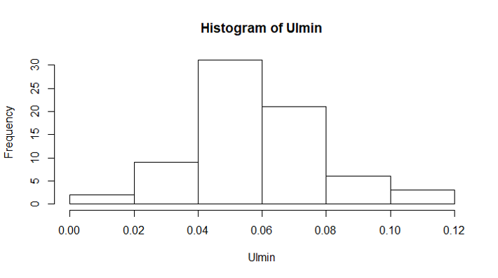

### My histogram:

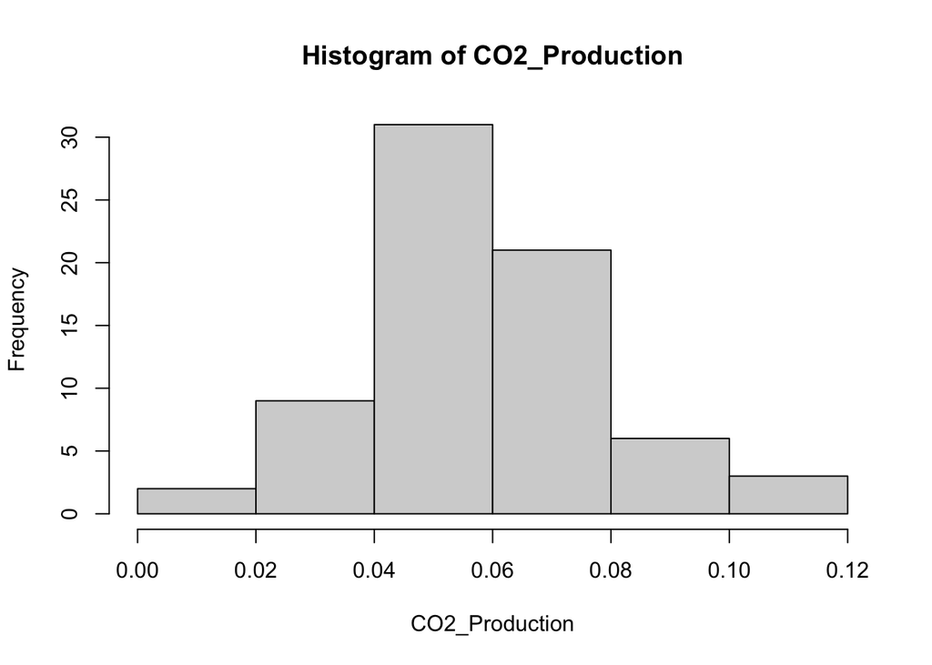

```r
CO2_Production <- mf_rest$CO2.prod.uL.min
hist(CO2_Production, plot = TRUE)
```

## Step 5. Inferential statistical analysis: Generalized linear mixed-effects modelling of sex differences on MR

The issue that I’ve been having with glmer is that in the paper, there was a designated variable “date” and in the data on dryad, the variable is age, which has a different numerical value (3) as opposed to date (2). This has affected my results and I have not been able to replicate them exactly. Collin describes this as an “oversight” but says that age should work the same. But it doesn’t. It’s close! But it’s not exactly the same. So that’s what we’re working with right now. On a different note, the authors gave the absolute value of the Wald t-statistic, so all of the resulting negative t-statistics are given in their absolute values in this analysis.

This one was the closest to the results in the paper: "sex was not a significant predictor of MR (Wald t = 0.24, P = 0.81)

```r
glmertry <- glmer(CO2.prod.uL.min ~ Mass * Sex + Act + chamber + (batch|Age), family= "Gamma", data = mf_exposed)
summary(glmertry)
```

```
## Generalized linear mixed model fit by maximum likelihood (Laplace
##   Approximation) [glmerMod]
##  Family: Gamma  ( inverse )
## Formula: CO2.prod.uL.min ~ Mass * Sex + Act + chamber + (batch | Age)
##    Data: mf_exposed
##
##      AIC      BIC   logLik deviance df.resid
##   -267.8   -233.4    150.9   -301.8       39
##
## Scaled residuals:
##      Min       1Q   Median       3Q      Max
## -1.72283 -0.64131 -0.05564  0.54827  2.91631
##
## Random effects:
##  Groups   Name        Variance Std.Dev. Corr
##  Age      (Intercept) 1.29261  1.1369
##           batchii     1.29444  1.1377   -1.00
##           batchiii    1.29431  1.1377   -1.00  1.00
##           batchiv     1.12820  1.0622    0.07 -0.09 -0.08
##  Residual             0.05885  0.2426
## Number of obs: 56, groups:  Age, 3
##
## Fixed effects:
##             Estimate Std. Error t value Pr(>|z|)
## (Intercept)  28.3972     5.8898   4.821 1.43e-06 ***
## Mass         -6.8319     2.2488  -3.038  0.00238 **
## SexM         -5.4632     9.3640  -0.583  0.55961
## Act          -8.9907     2.1500  -4.182 2.89e-05 ***
## chamber       0.6987     0.1110   6.296 3.06e-10 ***
## Mass:SexM     0.9922     4.4722   0.222  0.82442
## ---
## Signif. codes:  0 '***' 0.001 '**' 0.01 '*' 0.05 '.' 0.1 ' ' 1
##
## Correlation of Fixed Effects:
##           (Intr) Mass   SexM   Act    chambr
## Mass      -0.975
## SexM      -0.388  0.351
## Act        0.153 -0.192 -0.156
## chamber   -0.097 -0.024  0.111  0.386
## Mass:SexM  0.252 -0.213 -0.985  0.112 -0.129
## optimizer (Nelder_Mead) convergence code: 0 (OK)
## Model failed to converge with max|grad| = 0.0214291 (tol = 0.002, component 1)
```

```r
Ulmin ~ Mass * Sex + Act + chamber + (batch | date)
```

```
## Ulmin ~ Mass * Sex + Act + chamber + (batch | date)
```

From Results section 3.2.1. This test was the closest to the results in the paper: “sex was not a significant predictor of MR (Wald t = 0.24, P = 0.81).”

```r
glmertry <- glmer(CO2.prod.uL.min ~ Mass * Sex + Act + chamber + (batch|Age), family= "Gamma", data = mf_exposed)
summary(glmertry)
```

```
## Generalized linear mixed model fit by maximum likelihood (Laplace
##   Approximation) [glmerMod]
##  Family: Gamma  ( inverse )
## Formula: CO2.prod.uL.min ~ Mass * Sex + Act + chamber + (batch | Age)
##    Data: mf_exposed
##
##      AIC      BIC   logLik deviance df.resid
##   -267.8   -233.4    150.9   -301.8       39
##
## Scaled residuals:
##      Min       1Q   Median       3Q      Max
## -1.72283 -0.64131 -0.05564  0.54827  2.91631
##
## Random effects:
##  Groups   Name        Variance Std.Dev. Corr
##  Age      (Intercept) 1.29261  1.1369
##           batchii     1.29444  1.1377   -1.00
##           batchiii    1.29431  1.1377   -1.00  1.00
##           batchiv     1.12820  1.0622    0.07 -0.09 -0.08
##  Residual             0.05885  0.2426
## Number of obs: 56, groups:  Age, 3
##
## Fixed effects:
##             Estimate Std. Error t value Pr(>|z|)
## (Intercept)  28.3972     5.8898   4.821 1.43e-06 ***
## Mass         -6.8319     2.2488  -3.038  0.00238 **
## SexM         -5.4632     9.3640  -0.583  0.55961
## Act          -8.9907     2.1500  -4.182 2.89e-05 ***
## chamber       0.6987     0.1110   6.296 3.06e-10 ***
## Mass:SexM     0.9922     4.4722   0.222  0.82442
## ---
## Signif. codes:  0 '***' 0.001 '**' 0.01 '*' 0.05 '.' 0.1 ' ' 1
##
## Correlation of Fixed Effects:
##           (Intr) Mass   SexM   Act    chambr
## Mass      -0.975
## SexM      -0.388  0.351
## Act        0.153 -0.192 -0.156
## chamber   -0.097 -0.024  0.111  0.386
## Mass:SexM  0.252 -0.213 -0.985  0.112 -0.129
## optimizer (Nelder_Mead) convergence code: 0 (OK)
## Model failed to converge with max|grad| = 0.0214291 (tol = 0.002, component 1)
```

```r
Ulmin ~ Mass * Sex + Act + chamber + (batch | date)
```

```
## Ulmin ~ Mass * Sex + Act + chamber + (batch | date)
```

This test was pretty close to the results in the paper, my results being t=0.22 and p=0.82. Not bad.

Here we are using chamber as a predictor, no sex, no mass. “Chamber was a significant predictor in the exposed condition model of MR (Wald t = 5.84, P<0.0001).” This also shows that activity is significant (when using the absolute value of the t-statistic): “activity was a significant predictor of MR (Wald t = 4.47, P<0.0001).”

```r
glmercham <- glmer(CO2.prod.uL.min * 100 ~ Act + chamber + (batch|Age), family= "Gamma", data = mf_exposed)
```

```
## boundary (singular) fit: see ?isSingular
```

```r
summary(glmercham)
```

```
## Generalized linear mixed model fit by maximum likelihood (Laplace
##   Approximation) [glmerMod]
##  Family: Gamma  ( inverse )
## Formula: CO2.prod.uL.min * 100 ~ Act + chamber + (batch | Age)
##    Data: mf_exposed
##
##      AIC      BIC   logLik deviance df.resid
##    251.7    280.0   -111.8    223.7       42
##
## Scaled residuals:
##      Min       1Q   Median       3Q      Max
## -1.46278 -0.74071  0.02561  0.57899  2.52208
##
## Random effects:
##  Groups   Name        Variance  Std.Dev. Corr
##  Age      (Intercept) 0.0000000 0.00000
##           batchii     0.0003574 0.01890   NaN
##           batchiii    0.0001426 0.01194   NaN 0.70
##           batchiv     0.0008948 0.02991   NaN 0.70 1.00
##  Residual             0.0749453 0.27376
## Number of obs: 56, groups:  Age, 3
##
## Fixed effects:
##              Estimate Std. Error t value Pr(>|z|)
## (Intercept)  0.141924   0.017400   8.157 3.45e-16 ***
## Act         -0.094940   0.021219  -4.474 7.66e-06 ***
## chamber      0.006954   0.001188   5.854 4.81e-09 ***
## ---
## Signif. codes:  0 '***' 0.001 '**' 0.01 '*' 0.05 '.' 0.1 ' ' 1
##
## Correlation of Fixed Effects:
##         (Intr) Act
## Act     -0.810
## chamber -0.538  0.389
## optimizer (Nelder_Mead) convergence code: 0 (OK)
## boundary (singular) fit: see ?isSingular
```

```r
Formula: Ulmin * 100 ~ Act + chamber + (batch | date)
```

```
## Formula:Ulmin * 100 ~ Act + chamber + (batch | date)
```

This test was also pretty close. My results for chamber as a predictor: t=5.85, p= <0.0001. My results for activity as a predictor: t=4.47 (absolute value), p= <0.0001.

“In models with mass as a predictor, but not sex, mass significantly predicted MR in the exposed condition (Wald t = 2.27, P = 0.023).”

```r
expmassglmer <- glmer(CO2.prod.uL.min ~ Mass + Act + chamber +(batch|Age), family= "Gamma", data = mf_exposed)
```

```
## boundary (singular) fit: see ?isSingular
```

```r
summary(expmassglmer)
```

```
## Generalized linear mixed model fit by maximum likelihood (Laplace
##   Approximation) [glmerMod]
##  Family: Gamma  ( inverse )
## Formula: CO2.prod.uL.min ~ Mass + Act + chamber + (batch | Age)
##    Data: mf_exposed
##
##      AIC      BIC   logLik deviance df.resid
##   -267.2   -236.8    148.6   -297.2       41
##
## Scaled residuals:
##      Min       1Q   Median       3Q      Max
## -1.71110 -0.77246 -0.08648  0.69197  2.85896
##
## Random effects:
##  Groups   Name        Variance Std.Dev. Corr
##  Age      (Intercept) 2.70541  1.6448
##           batchii     2.70720  1.6454   -1.00
##           batchiii    2.51479  1.5858   -1.00  1.00
##           batchiv     0.92300  0.9607   -0.03  0.03  0.05
##  Residual             0.06419  0.2534
## Number of obs: 56, groups:  Age, 3
##
## Fixed effects:
##             Estimate Std. Error t value Pr(>|z|)
## (Intercept)  17.7896     3.1621   5.626 1.85e-08 ***
## Mass         -2.7392     1.2492  -2.193   0.0283 *
## Act         -10.3034     2.0623  -4.996 5.85e-07 ***
## chamber       0.6809     0.1129   6.029 1.65e-09 ***
## ---
## Signif. codes:  0 '***' 0.001 '**' 0.01 '*' 0.05 '.' 0.1 ' ' 1
##
## Correlation of Fixed Effects:
##         (Intr) Mass   Act
## Mass    -0.919
## Act     -0.269  0.150
## chamber -0.293  0.063  0.389
## optimizer (Nelder_Mead) convergence code: 4 (failure to converge in 10000 evaluations)
## boundary (singular) fit: see ?isSingular
## failure to converge in 10000 evaluations
```

Also close, my results being t=2.19 (absolute), p=0.028. Not exactly, but as close as I could get it.

##Step 6. Recreating figures A and B from Figure 2

## Grouped boxplot of fly responses to mite exposure. A) Metabolic rates of male and female flies at rest or exposed to mites. B) Activity of male and female flies at rest or exposed to mites.

### Horn et al figure 2A:

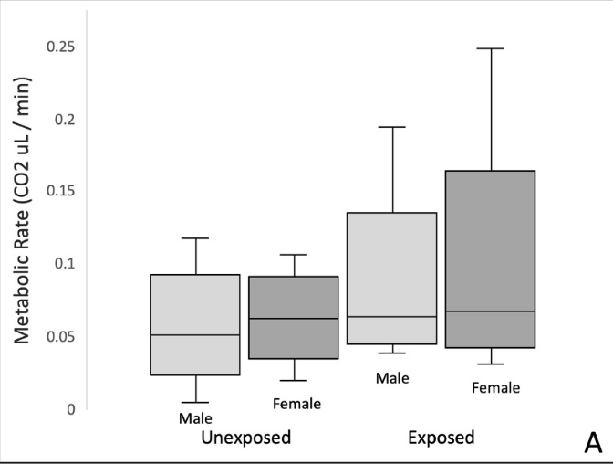

### My figure 2A:

```r
mf_rest1 <- read.csv("mf_CO2_2.csv", header = TRUE, stringsAsFactors = FALSE)

#define variables
treatment=rep(c('Exposed', 'Unexposed'), 'Exposed'=56, 'Unexposed'=72)
Sex=rep(c('Male', 'Female'), each=64)
CO2=mf_rest1$CO2

data=data.frame(treatment, Sex, CO2)
summary(data)
```

```
##   treatment             Sex                 CO2
##  Length:128         Length:128         Min.   :0.00474
##  Class :character   Class :character   1st Qu.:0.04757
##  Mode  :character   Mode  :character   Median :0.06115
##                                        Mean   :0.06447
##                                        3rd Qu.:0.07240
##                                        Max.   :0.24900
```

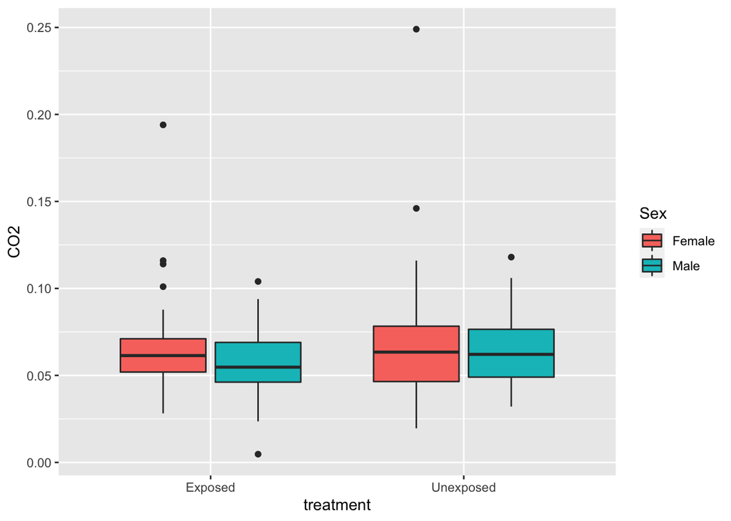

```r
ggplot(data, aes(x=treatment, y=CO2, fill=Sex)) +
         geom_boxplot()
```

### Horn et al figure 2B:

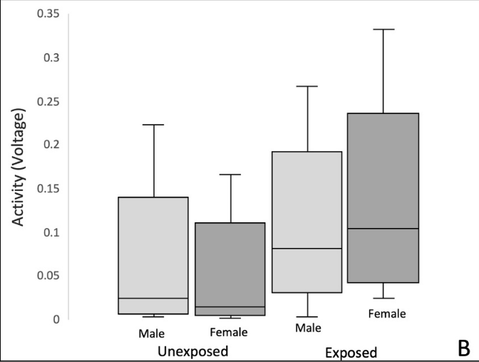

### My figure 2B:

```r
mf_rest_act <- read.csv("mf_act_2.csv", header = TRUE, stringsAsFactors = FALSE)

#define variables
treatment=rep(c('Exposed', 'Unexposed'), 'Exposed'=56, 'Unexposed'=72)
Sex=rep(c('Male', 'Female'), each=64)
Activity=mf_rest_act$Activity

data=data.frame(treatment, Sex, Activity)
summary(data)
```

```
##   treatment             Sex               Activity
##  Length:128         Length:128         Min.   :0.00169
##  Class :character   Class :character   1st Qu.:0.01383
##  Mode  :character   Mode  :character   Median :0.05480
##                                        Mean   :0.07498
##                                        3rd Qu.:0.09500
##                                        Max.   :1.02000
```

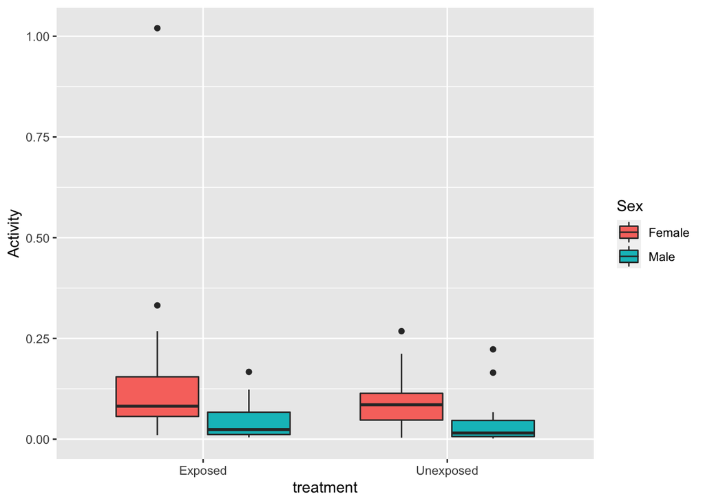

```r
ggplot(data, aes(x=treatment, y=Activity, fill=Sex)) +
  geom_boxplot()
```

## Concluding Remarks

Replication of scientific analyses is a cornerstone to scientific research. If the analyses are not reproducible, it may not bode well for the overall reliability of the study. Fortunately, “Extending the ecology of fear: Parasite-mediated sexual selection drives host response to parasites” was relatively reproducible, even for an Rstudio novice like me. While there were a few hiccups, such as using the “age” variable as a proxy for the original “date”, as well as excluding the results of the “Y-maze experiment” (I did not mention this because these data were just not part of the available dataset on dryad), there were no egregious differences. I’m guessing that most of the discrepancies were due to my intermediate skill at coding and statistics, especially when considering the grouped boxplots. It also speaks well of the authors for being so generous with their material and so willing to answer the questions of a stranger. They, too, must value highly the degree of replicability in a scientific study.

## Blooper Reel!!

### Here’s the stuff that just… didn’t work.

CO2 virgin and mated. Differing number of rows here which gave me trouble, so I got rid of one of the exposed virgins with an activity level “NA”. This did not work.

```r
fem_CO2 <- read.csv("fem_CO2_2.csv", header = TRUE, stringsAsFactors = FALSE)

#define variables
treatment=rep(c('Exposed', 'Unexposed'), 'Exposed'=69, 'Unexposed'=55)
Virginity_status=rep(c('Virgin', 'Mated'), each=62)
CO2=fem_CO2$CO2

data=data.frame(treatment, Virginity_status, CO2)
```

```
## Error in data.frame(treatment, Virginity_status, CO2): arguments imply differing number of rows: 2, 124, 125
```

```r
summary(data)
```

```
##   treatment             Sex               Activity
##  Length:128         Length:128         Min.   :0.00169
##  Class :character   Class :character   1st Qu.:0.01383
##  Mode  :character   Mode  :character   Median :0.05480
##                                        Mean   :0.07498
##                                        3rd Qu.:0.09500
##                                        Max.   :1.02000
```

```r
ggplot(data, aes(x=treatment, y=CO2, fill=Virginity_status)) +
  geom_boxplot()
```

```
## Error: Aesthetics must be either length 1 or the same as the data (128): y and fill
```

Trying more with ggplot. This did not work. Created what feels like a thousand csvs to organize the data, but at what cost… at what cost.

```r
fem_exposed_mr <- fem_exposed$CO2.prod.uL.min
fem_rest_mr <- fem_rest$CO2.prod.uL.min
male_exposed_mr <- male_exposed$CO2.prod.uL.min
male_rest_mr <- male_rest$CO2.prod.uL.min
```

```
## Error in eval(expr, envir, enclos): object 'male_rest' not found
```

```r
fem_exposed_mr <- read.csv("fem_exposed_mr.csv", header = TRUE, stringsAsFactors = FALSE)
fem_rest_mr <- read.csv("fem_rest_mr.csv", header = TRUE, stringsAsFactors = FALSE)
male_exposed_mr <- read.csv("male_exposed_mr.csv", header = TRUE, stringsAsFactors = FALSE)
male_rest_mr <- read.csv("male_rest_mr.csv", header = TRUE, stringsAsFactors = FALSE)

boxplot(fem_exposed_mr, fem_rest_mr, male_exposed_mr, male_rest_mr)
```

```
## Error in x[floor(d)] + x[ceiling(d)]: non-numeric argument to binary operator
```

```r
fem_exposed_mr$CO2.prod.uL.min <- as.factor(fem_exposed_mr$CO2.prod.uL.min )
head(fem_exposed_mr)
```

```
##   Code chamber   Sex Mass CO2.prod.uL.min
## 1   F1       2 FALSE 1.87          0.0586
## 2   F2       4 FALSE 2.19          0.0635
## 3   F3       6 FALSE 2.31          0.0337
## 4   F4       8 FALSE 2.05          0.0387
## 5   F5      10 FALSE 2.97           0.043
## 6   F6      12 FALSE 2.28          0.0526
```

```r
fem_rest_mr$CO2.prod.uL.min <- as.factor(fem_rest_mr$CO2.prod.uL.min )
head(fem_rest_mr)
```

```
##   Code chamber   Sex Mass CO2.prod.uL.min
## 1   F1       1 FALSE 2.63           0.104
## 2   F2       3 FALSE 2.31           0.106
## 3   F3       5 FALSE 2.52           0.047
## 4   F4       7 FALSE 2.32          0.0664
## 5   F5       9 FALSE 2.68            0.07
## 6   F6      11 FALSE 2.66          0.0445
```

```r
male_exposed_mr$CO2.prod.uL.min <- as.factor(male_exposed_mr$CO2.prod.uL.min )
head(male_exposed_mr)
```

```
##   Code chamber Sex Mass CO2.prod.uL.min
## 1   M1       1   M 1.84           0.194
## 2   M2       3   M 1.65           0.104
## 3   M3       5   M 1.83          0.0671
## 4   M4       7   M 1.89          0.0452
## 5   M5       9   M 1.79          0.0632
## 6   M6      11   M 1.74          0.0381
```

```r
male_rest_mr$CO2.prod.uL.min <- as.factor(male_rest_mr$CO2.prod.uL.min )
head(male_rest_mr)
```

```
##   Code chamber Sex Mass CO2.prod.uL.min
## 1   M1       2   M 1.60           0.087
## 2   M2       4   M 2.05           0.118
## 3   M3       6   M 2.28          0.0662
## 4   M4       8   M 2.09          0.0686
## 5   M5      10   M 2.10          0.0555
## 6   M6      12   M 2.02          0.0482
```

```r
library(ggplot2)
ggplot() +
  geom_boxplot((data = fem_exposed_mr + fem_rest_mr + male_exposed_mr + male_rest_mr), mapping = aes(col_name, value, fill=index))  +
  theme( axis.text.x = element_blank()) +
  geom_segment(data=hline1, mapping=aes(x=1, y=-0.5, xend=3, yend=-0.5), size=2) +
  annotate("text", x = 2, y = -1, label = "A") +
  geom_segment(data=hline1, mapping=aes(x=4, y=-0.5, xend=6, yend=-0.5), size=2) +
  annotate("text", x = 5, y = -1, label = "B")
```

```
## Error in Ops.data.frame(fem_exposed_mr, fem_rest_mr): '+' only defined for equally-sized data frames
```

```r
cols <- rainbow(3, s = 0.5)
boxplot(x ~ z + y, data = DF2,
        at = c(1:3, 5:7), col = cols,
        names = c("", "A", "", "", "B", ""), xaxs = FALSE)
```

```
## Error in eval(m$data, parent.frame()): object 'DF2' not found
```

```r
legend("topleft", fill = cols, legend = c(1,2,3), horiz = T)
```

```
## Error in strwidth(legend, units = "user", cex = cex, font = text.font): plot.new has not been called yet
```

Trying to calculate average weight for male flies at rest using dplyr and merging of csvs

```r
male_rest <- mf_rest %>% filter(Sex == "M")
male_rest
```

```
##    Code chamber Sex Mass CO2.prod.uL.min    VCOsd Age     Act batch
## 1    M1       2   M 1.60         0.08700 4.09e-06  20 0.03100   One
## 2    M2       4   M 2.05         0.11800 8.62e-06  20 0.00718   One
## 3    M3       6   M 2.28         0.06620 2.18e-06  20 0.05910   One
## 4    M4       8   M 2.09         0.06860 2.95e-06  20 0.00697   One
## 5    M5      10   M 2.10         0.05550 3.79e-06  20 0.02340   One
## 6    M6      12   M 2.02         0.04820 3.12e-06  20 0.06690   One
## 7    M7       1   M 1.48         0.04180 3.48e-06  15 0.08940   Two
## 8    M8       3   M 1.82         0.08530 4.56e-06  15 0.03230   Two
## 9    M9       5   M 2.18         0.05380 2.38e-06  15 0.02500   Two
## 10  M10       7   M 2.46         0.06820 3.47e-06  15 0.06500   Two
## 11  M11       9   M 1.69         0.04360 3.26e-06  15 0.02950   Two
## 12  M12      11   M 1.66         0.03210 2.62e-06  15 0.22300   Two
## 13  M13       2   M 2.36         0.05220 3.07e-06  15 0.00456 Three
## 14  M14       4   M 3.27         0.07160 8.49e-06  15 0.00952 Three
```

[output cut: 22 more lines]

```r
summary(male_rest)
```

```
##      Code              chamber          Sex                 Mass
##  Length:36          Min.   : 1.00   Length:36          Min.   :1.480
##  Class :character   1st Qu.: 3.75   Class :character   1st Qu.:1.865
##  Mode  :character   Median : 6.50   Mode  :character   Median :2.180
##                     Mean   : 6.50                      Mean   :2.208
##                     3rd Qu.: 9.25                      3rd Qu.:2.410
##                     Max.   :12.00                      Max.   :3.460
##  CO2.prod.uL.min       VCOsd                Age          Act
##  Min.   :0.00474   Min.   :2.180e-06   Min.   :10   Min.   :0.00294
##  1st Qu.:0.04072   1st Qu.:3.230e-06   1st Qu.:10   1st Qu.:0.01033
##  Median :0.05050   Median :4.125e-06   Median :15   Median :0.02465
##  Mean   :0.05319   Mean   :5.361e-06   Mean   :15   Mean   :0.03983
##  3rd Qu.:0.06670   3rd Qu.:7.140e-06   3rd Qu.:20   3rd Qu.:0.05835
##  Max.   :0.11800   Max.   :1.290e-05   Max.   :20   Max.   :0.22300
##     batch
##  Length:36
##  Class :character
##  Mode  :character
##
##
##
```

Mean mass for males at rest is 2.208, which is closer, but still not the same. I will now try combining all males, both exposed and at rest, to see if I can get the same mean from the study. Since they are in two different .csv files, I will try and combine them into one column using the merge function.

The merge function did not work for me, so I instead created a new .csv file by copying and pasting values from excel to create a combined file of males at rest and exposed:

```r
male_combined <- read.csv("combined_mf.csv", header = TRUE, stringsAsFactors = FALSE)
summary(male_combined$Mass)
```

```
##    Min. 1st Qu.  Median    Mean 3rd Qu.    Max.
##   1.610   2.228   2.470   2.450   2.715   3.240
```

Mixed effects modeling to control for sexual dimorphism. Females are typically heavier. Now running two different mixed efects models (MEM) which did not give me useful information. I did this more successfully above.

```r
massEEErestMF <- lmer(CO2.prod.uL.min ~ Age + Mass + chamber + (1|batch), data= mf_rest)
summary(massEEErestMF)
```

```
## Linear mixed model fit by REML. t-tests use Satterthwaite's method [
## lmerModLmerTest]
## Formula: CO2.prod.uL.min ~ Age + Mass + chamber + (1 | batch)
##    Data: mf_rest
##
## REML criterion at convergence: -339.8
##
## Scaled residuals:
##      Min       1Q   Median       3Q      Max
## -2.52532 -0.64051  0.02341  0.57266  2.58492
##
## Random effects:
##  Groups   Name        Variance  Std.Dev.
##  batch    (Intercept) 1.057e-05 0.003251
##  Residual             2.860e-04 0.016911
## Number of obs: 72, groups:  batch, 6
##
## Fixed effects:
##               Estimate Std. Error         df t value Pr(>|t|)
## (Intercept)  0.0255411  0.0167658 28.6698918   1.523  0.13861
## Age          0.0022451  0.0006146  4.5926158   3.653  0.01707 *
## Mass         0.0052076  0.0047864 67.9091407   1.088  0.28044
## chamber     -0.0020577  0.0005790 63.9814777  -3.554  0.00072 ***
## ---
## Signif. codes:  0 '***' 0.001 '**' 0.01 '*' 0.05 '.' 0.1 ' ' 1
##
## Correlation of Fixed Effects:
##         (Intr) Age    Mass
## Age     -0.742
## Mass    -0.809  0.299
## chamber -0.162 -0.023 -0.076
```

```r
anova(massEEErestMF, test = 'Chisq')
```

```
## Type III Analysis of Variance Table with Satterthwaite's method
##            Sum Sq   Mean Sq NumDF  DenDF F value    Pr(>F)
## Age     0.0038160 0.0038160     1  4.593 13.3434 0.0170693 *
## Mass    0.0003385 0.0003385     1 67.909  1.1838 0.2804382
## chamber 0.0036118 0.0036118     1 63.981 12.6296 0.0007197 ***
## ---
## Signif. codes:  0 '***' 0.001 '**' 0.01 '*' 0.05 '.' 0.1 ' ' 1
```

```r
sexEEErestMF <- lmer(CO2.prod.uL.min ~ Age + Sex + chamber + (1|batch), data= mf_rest)
summary(sexEEErestMF)
```

```
## Linear mixed model fit by REML. t-tests use Satterthwaite's method [
## lmerModLmerTest]
## Formula: CO2.prod.uL.min ~ Age + Sex + chamber + (1 | batch)
##    Data: mf_rest
##
## REML criterion at convergence: -344.1
##
## Scaled residuals:
##      Min       1Q   Median       3Q      Max
## -2.35390 -0.62481 -0.01316  0.61877  2.90688
##
## Random effects:
##  Groups   Name        Variance  Std.Dev.
##  batch    (Intercept) 1.765e-05 0.004201
##  Residual             2.635e-04 0.016234
## Number of obs: 72, groups:  batch, 6
##
## Fixed effects:
##               Estimate Std. Error         df t value Pr(>|t|)
## (Intercept)  0.0450120  0.0106003  5.5007490   4.246 0.006566 **
## Age          0.0020453  0.0006294  3.9999995   3.250 0.031387 *
## SexM        -0.0094350  0.0038263 64.0000007  -2.466 0.016360 *
## chamber     -0.0020097  0.0005542 64.0000007  -3.626 0.000571 ***
## ---
## Signif. codes:  0 '***' 0.001 '**' 0.01 '*' 0.05 '.' 0.1 ' ' 1
##
## Correlation of Fixed Effects:
##         (Intr) Age    SexM
## Age     -0.891
## SexM    -0.180  0.000
## chamber -0.340  0.000  0.000
```

```r
anova(sexEEErestMF, test = 'Chisq')
```

```
## Type III Analysis of Variance Table with Satterthwaite's method
##            Sum Sq   Mean Sq NumDF DenDF F value    Pr(>F)
## Age     0.0027829 0.0027829     1     4 10.5600 0.0313872 *
## Sex     0.0016023 0.0016023     1    64  6.0804 0.0163600 *
## chamber 0.0034653 0.0034653     1    64 13.1497 0.0005711 ***
## ---
## Signif. codes:  0 '***' 0.001 '**' 0.01 '*' 0.05 '.' 0.1 ' ' 1
```

Exposed treatment: mass specific analysis from Collin Horn’s exposed analysis doc. Messing around with that code here:

```r
expmassglmer <- glmer(CO2.prod.uL.min ~ Mass + Act + chamber +(batch|Age), family= "Gamma", data = mf_exposed)
```

```
## boundary (singular) fit: see ?isSingular
```

```r
summary(expmassglmer)
```

```
## Generalized linear mixed model fit by maximum likelihood (Laplace
##   Approximation) [glmerMod]
##  Family: Gamma  ( inverse )
## Formula: CO2.prod.uL.min ~ Mass + Act + chamber + (batch | Age)
##    Data: mf_exposed
##
##      AIC      BIC   logLik deviance df.resid
##   -267.2   -236.8    148.6   -297.2       41
##
## Scaled residuals:
##      Min       1Q   Median       3Q      Max
## -1.71110 -0.77246 -0.08648  0.69197  2.85896
##
## Random effects:
##  Groups   Name        Variance Std.Dev. Corr
##  Age      (Intercept) 2.70541  1.6448
##           batchii     2.70720  1.6454   -1.00
##           batchiii    2.51479  1.5858   -1.00  1.00
##           batchiv     0.92300  0.9607   -0.03  0.03  0.05
##  Residual             0.06419  0.2534
## Number of obs: 56, groups:  Age, 3
##
## Fixed effects:
##             Estimate Std. Error t value Pr(>|z|)
## (Intercept)  17.7896     3.1621   5.626 1.85e-08 ***
## Mass         -2.7392     1.2492  -2.193   0.0283 *
## Act         -10.3034     2.0623  -4.996 5.85e-07 ***
## chamber       0.6809     0.1129   6.029 1.65e-09 ***
## ---
## Signif. codes:  0 '***' 0.001 '**' 0.01 '*' 0.05 '.' 0.1 ' ' 1
##
## Correlation of Fixed Effects:
##         (Intr) Mass   Act
## Mass    -0.919
## Act     -0.269  0.150
## chamber -0.293  0.063  0.389
## optimizer (Nelder_Mead) convergence code: 4 (failure to converge in 10000 evaluations)
## boundary (singular) fit: see ?isSingular
## failure to converge in 10000 evaluations
```

```r
ulminmg ~ Sex * Act + chamber + (batch | date)
```

```
## ulminmg ~ Sex * Act + chamber + (batch | date)
```

```r
Ulmin ~ Mass * Sex + Act + chamber + (batch | date)
```

```
## Ulmin ~ Mass * Sex + Act + chamber + (batch | date)
```

```r
expplusglmer <- glmer(CO2.prod.uL.min ~ Sex + Act + chamber + (batch|Age), family= "Gamma", data = mf_exposed)
```

```
## boundary (singular) fit: see ?isSingular
```

```r
summary(expplusglmer)
```

```
## Generalized linear mixed model fit by maximum likelihood (Laplace
##   Approximation) [glmerMod]
##  Family: Gamma  ( inverse )
## Formula: CO2.prod.uL.min ~ Sex + Act + chamber + (batch | Age)
##    Data: mf_exposed
##
##      AIC      BIC   logLik deviance df.resid
##   -262.9   -232.6    146.5   -292.9       41
##
## Scaled residuals:
##      Min       1Q   Median       3Q      Max
## -1.57800 -0.77727 -0.01127  0.59823  2.44817
##
## Random effects:
##  Groups   Name        Variance Std.Dev. Corr
##  Age      (Intercept) 3.83027  1.9571
##           batchii     3.83537  1.9584   -1.00
##           batchiii    3.58984  1.8947   -1.00  1.00
##           batchiv     0.20686  0.4548    0.30 -0.30 -0.30
##  Residual             0.06963  0.2639
## Number of obs: 56, groups:  Age, 3
##
## Fixed effects:
##             Estimate Std. Error t value Pr(>|z|)
## (Intercept)  11.3235     1.3277   8.529  < 2e-16 ***
## SexM          0.5524     0.9023   0.612     0.54
## Act          -9.9899     2.1817  -4.579 4.67e-06 ***
## chamber       0.6888     0.1182   5.827 5.64e-09 ***
## ---
## Signif. codes:  0 '***' 0.001 '**' 0.01 '*' 0.05 '.' 0.1 ' ' 1
##
## Correlation of Fixed Effects:
##         (Intr) SexM   Act
## SexM    -0.217
## Act     -0.277 -0.275
## chamber -0.572 -0.082  0.393
## optimizer (Nelder_Mead) convergence code: 0 (OK)
## boundary (singular) fit: see ?isSingular
```

```r
Formula: ulminmg ~ Sex + Act + chamber + (batch | date)
```

```
## Formula:ulminmg ~ Sex + Act + chamber + (batch | date)
```

```r
shapiro.test(resid(expplusglmer))
```

```
##
##  Shapiro-Wilk normality test
##
## data:  resid(expplusglmer)
## W = 0.97904, p-value = 0.4357
```

With the exposed condition the data was slightly right skewed so the authors used a Gamma distribution and the glmer function. Trying to figure out how to get t statistic and really trying to make glmer my friend. Why is your cousin lmer so much more agreeable? Please take a hint from her and get some lessons in etiquette!!

```r
EEEexpMF <- glmer(CO2.prod.uL.min ~ Age + Sex + Mass + (chamber|batch), family= "Gamma", data = mf_exposed)
```

```
## boundary (singular) fit: see ?isSingular
```

```r
EEEexpMF
```

```
## Generalized linear mixed model fit by maximum likelihood (Laplace
##   Approximation) [glmerMod]
##  Family: Gamma  ( inverse )
## Formula: CO2.prod.uL.min ~ Age + Sex + Mass + (chamber | batch)
##    Data: mf_exposed
##       AIC       BIC    logLik  deviance  df.resid
## -277.3006 -261.0978  146.6503 -293.3006        48
## Random effects:
##  Groups   Name        Std.Dev. Corr
##  batch    (Intercept) 4.8538
##           chamber     0.5201   -1.00
##  Residual             0.2679
## Number of obs: 56, groups:  batch, 4
## Fixed Effects:
## (Intercept)          Age         SexM         Mass
##     33.1544       0.4137      -5.2260      -9.0800
## optimizer (Nelder_Mead) convergence code: 0 (OK) ; 0 optimizer warnings; 1 lme4 warnings
```

```r
glmer <- glmer(CO2.prod.uL.min ~ Sex + Act + Mass + (chamber|batch), family= "Gamma", data = mf_exposed)
glmer
```

```
## Generalized linear mixed model fit by maximum likelihood (Laplace
##   Approximation) [glmerMod]
##  Family: Gamma  ( inverse )
## Formula: CO2.prod.uL.min ~ Sex + Act + Mass + (chamber | batch)
##    Data: mf_exposed
##       AIC       BIC    logLik  deviance  df.resid
## -283.5299 -267.3271  149.7650 -299.5299        48
## Random effects:
##  Groups   Name        Std.Dev. Corr
##  batch    (Intercept) 3.1662
##           chamber     0.4548   -0.94
##  Residual             0.2478
## Number of obs: 56, groups:  batch, 4
## Fixed Effects:
## (Intercept)         SexM          Act         Mass
##      34.572       -3.922       -7.159       -7.546
```

```r
summary(glmer)
```

```
## Generalized linear mixed model fit by maximum likelihood (Laplace
##   Approximation) [glmerMod]
##  Family: Gamma  ( inverse )
## Formula: CO2.prod.uL.min ~ Sex + Act + Mass + (chamber | batch)
##    Data: mf_exposed
##
##      AIC      BIC   logLik deviance df.resid
##   -283.5   -267.3    149.8   -299.5       48
##
## Scaled residuals:
##      Min       1Q   Median       3Q      Max
## -1.75498 -0.63448  0.00461  0.56102  2.57707
##
## Random effects:
##  Groups   Name        Variance Std.Dev. Corr
##  batch    (Intercept) 10.02472 3.1662
##           chamber      0.20680 0.4548   -0.94
##  Residual              0.06138 0.2478
## Number of obs: 56, groups:  batch, 4
##
## Fixed effects:
##             Estimate Std. Error t value Pr(>|z|)
## (Intercept)   34.572      5.720   6.044  1.5e-09 ***
## SexM          -3.922      1.528  -2.568  0.01024 *
## Act           -7.159      2.718  -2.634  0.00843 **
## Mass          -7.546      2.150  -3.509  0.00045 ***
## ---
## Signif. codes:  0 '***' 0.001 '**' 0.01 '*' 0.05 '.' 0.1 ' ' 1
##
## Correlation of Fixed Effects:
##      (Intr) SexM   Act
## SexM -0.821
## Act   0.072 -0.271
## Mass -0.924  0.851 -0.225
```

```r
glmernosex <- glmer(CO2.prod.uL.min ~ Act + Mass + (chamber|batch), family= "Gamma", data = mf_exposed)
glmernosex
```

```
## Generalized linear mixed model fit by maximum likelihood (Laplace
##   Approximation) [glmerMod]
##  Family: Gamma  ( inverse )
## Formula: CO2.prod.uL.min ~ Act + Mass + (chamber | batch)
##    Data: mf_exposed
##       AIC       BIC    logLik  deviance  df.resid
## -278.9709 -264.7934  146.4854 -292.9709        49
## Random effects:
##  Groups   Name        Std.Dev. Corr
##  batch    (Intercept) 3.3541
##           chamber     0.4397   -0.90
##  Residual             0.2621
## Number of obs: 56, groups:  batch, 4
## Fixed Effects:
## (Intercept)          Act         Mass
##      22.974       -9.323       -2.884
```

```r
summary(glmernosex)
```

```
## Generalized linear mixed model fit by maximum likelihood (Laplace
##   Approximation) [glmerMod]
##  Family: Gamma  ( inverse )
## Formula: CO2.prod.uL.min ~ Act + Mass + (chamber | batch)
##    Data: mf_exposed
##
##      AIC      BIC   logLik deviance df.resid
##   -279.0   -264.8    146.5   -293.0       49
##
## Scaled residuals:
##     Min      1Q  Median      3Q     Max
## -1.7142 -0.7273  0.1399  0.5643  2.6420
##
## Random effects:
##  Groups   Name        Variance Std.Dev. Corr
##  batch    (Intercept) 11.25009 3.3541
##           chamber      0.19331 0.4397   -0.90
##  Residual              0.06868 0.2621
## Number of obs: 56, groups:  batch, 4
##
## Fixed effects:
##             Estimate Std. Error t value Pr(>|z|)
## (Intercept)   22.974      4.048   5.676 1.38e-08 ***
## Act           -9.323      2.877  -3.240  0.00119 **
## Mass          -2.884      1.235  -2.336  0.01950 *
## ---
## Signif. codes:  0 '***' 0.001 '**' 0.01 '*' 0.05 '.' 0.1 ' ' 1
##
## Correlation of Fixed Effects:
##      (Intr) Act
## Act  -0.368
## Mass -0.626  0.011
```

```r
anova(glmer, glmernosex, test = "Wald")
```

```
## Data: mf_exposed
## Models:
## glmernosex: CO2.prod.uL.min ~ Act + Mass + (chamber | batch)
## glmer: CO2.prod.uL.min ~ Sex + Act + Mass + (chamber | batch)
##            npar     AIC     BIC logLik deviance  Chisq Df Pr(>Chisq)
## glmernosex    7 -278.97 -264.79 146.49  -292.97
## glmer         8 -283.53 -267.33 149.76  -299.53 6.5591  1    0.01044 *
## ---
## Signif. codes:  0 '***' 0.001 '**' 0.01 '*' 0.05 '.' 0.1 ' ' 1
```

```r
wald.test(glmer, glmernosex, Terms = mf_exposed$sex)
```

```
## Error in wald.test(glmer, glmernosex, Terms = mf_exposed$sex): One of the arguments Terms or L must be used.
```

```r
summary(glmernosex, glmer)
```

```
## Error in if (correlation) rr@factors$correlation <- if (!is.na(sigm)) as(rr, : argument is not interpretable as logical
```

```r
glmernomass <- glmer(CO2.prod.uL.min ~ Act + Sex + (chamber|batch), family= "Gamma", data = mf_exposed)
summary(glmernomass)
```

```
## Generalized linear mixed model fit by maximum likelihood (Laplace
##   Approximation) [glmerMod]
##  Family: Gamma  ( inverse )
## Formula: CO2.prod.uL.min ~ Act + Sex + (chamber | batch)
##    Data: mf_exposed
##
##      AIC      BIC   logLik deviance df.resid
##   -274.1   -259.9    144.0   -288.1       49
##
## Scaled residuals:
##     Min      1Q  Median      3Q     Max
## -1.5327 -0.6204  0.0386  0.5046  2.3342
##
## Random effects:
##  Groups   Name        Variance Std.Dev. Corr
##  batch    (Intercept) 14.13940 3.7602
##           chamber      0.18775 0.4333   -0.89
##  Residual              0.07717 0.2778
## Number of obs: 56, groups:  batch, 4
##
## Fixed effects:
##             Estimate Std. Error t value Pr(>|z|)
## (Intercept)  17.0941     3.8704   4.417    1e-05 ***
## Act          -9.6323     3.1497  -3.058  0.00223 **
## SexM          0.4697     0.8801   0.534  0.59355
## ---
## Signif. codes:  0 '***' 0.001 '**' 0.01 '*' 0.05 '.' 0.1 ' ' 1
##
## Correlation of Fixed Effects:
##      (Intr) Act
## Act  -0.474
## SexM -0.110 -0.179
```

```r
EEEexpMF<- lmer(CO2.prod.uL.min~+Sex+Mass+(chamber|batch), data=mf_exposed)
```

```
## boundary (singular) fit: see ?isSingular
```

```r
summary(EEEexpMF)
```

```
## Linear mixed model fit by REML. t-tests use Satterthwaite's method [
## lmerModLmerTest]
## Formula: CO2.prod.uL.min ~ +Sex + Mass + (chamber | batch)
##    Data: mf_exposed
##
## REML criterion at convergence: -212.8
##
## Scaled residuals:
##     Min      1Q  Median      3Q     Max
## -1.8963 -0.5126 -0.0501  0.4706  3.8832
##
## Random effects:
##  Groups   Name        Variance  Std.Dev. Corr
##  batch    (Intercept) 2.609e-03 0.051078
##           chamber     2.825e-05 0.005315 -1.00
##  Residual             7.588e-04 0.027547
## Number of obs: 56, groups:  batch, 4
##
## Fixed effects:
##             Estimate Std. Error       df t value Pr(>|t|)
## (Intercept) -0.04296    0.03671 42.84725  -1.170  0.24838
## SexM         0.02344    0.01063 48.22713   2.204  0.03231 *
## Mass         0.04300    0.01464 43.32493   2.938  0.00528 **
## ---
## Signif. codes:  0 '***' 0.001 '**' 0.01 '*' 0.05 '.' 0.1 ' ' 1
##
## Correlation of Fixed Effects:
##      (Intr) SexM
## SexM -0.780
## Mass -0.989  0.718
## optimizer (nloptwrap) convergence code: 0 (OK)
## boundary (singular) fit: see ?isSingular
```

```r
glmernosex<- lmer(CO2.prod.uL.min~Age+Mass+(chamber|batch), data=mf_exposed)
```

```
## boundary (singular) fit: see ?isSingular
```

```r
summary(glmernosex)
```

```
## Linear mixed model fit by REML. t-tests use Satterthwaite's method [
## lmerModLmerTest]
## Formula: CO2.prod.uL.min ~ Age + Mass + (chamber | batch)
##    Data: mf_exposed
##
## REML criterion at convergence: -206.2
##
## Scaled residuals:
##     Min      1Q  Median      3Q     Max
## -1.9336 -0.5711 -0.0371  0.4018  3.6053
##
## Random effects:
##  Groups   Name        Variance  Std.Dev. Corr
##  batch    (Intercept) 3.814e-03 0.061757
##           chamber     2.765e-05 0.005259 -1.00
##  Residual             7.795e-04 0.027920
## Number of obs: 56, groups:  batch, 4
##
## Fixed effects:
##              Estimate Std. Error        df t value Pr(>|t|)
## (Intercept)  0.058144   0.034468 25.945964   1.687    0.104
## Age         -0.002268   0.001476  7.797339  -1.536    0.164
## Mass         0.014563   0.010643 49.090458   1.368    0.177
##
## Correlation of Fixed Effects:
##      (Intr) Age
## Age  -0.712
## Mass -0.734  0.071
## optimizer (nloptwrap) convergence code: 0 (OK)
## boundary (singular) fit: see ?isSingular
```

```r
glmernomass <-lmer(CO2.prod.uL.min~Age+Sex+(chamber|batch), data=mf_exposed)
```

```
## boundary (singular) fit: see ?isSingular
```

```r
summary(glmernomass)
```

```
## Linear mixed model fit by REML. t-tests use Satterthwaite's method [
## lmerModLmerTest]
## Formula: CO2.prod.uL.min ~ Age + Sex + (chamber | batch)
##    Data: mf_exposed
##
## REML criterion at convergence: -203.7
##
## Scaled residuals:
##     Min      1Q  Median      3Q     Max
## -1.7055 -0.6305 -0.1210  0.4555  3.6471
##
## Random effects:
##  Groups   Name        Variance  Std.Dev. Corr
##  batch    (Intercept) 4.102e-03 0.064046
##           chamber     2.717e-05 0.005213 -1.00
##  Residual             8.048e-04 0.028369
## Number of obs: 56, groups:  batch, 4
##
## Fixed effects:
##               Estimate Std. Error         df t value Pr(>|t|)
## (Intercept)  0.0936865  0.0258701  7.7694715   3.621  0.00711 **
## Age         -0.0026204  0.0015947  7.4468025  -1.643  0.14176
## SexM         0.0003646  0.0076193 48.7720767   0.048  0.96203
## ---
## Signif. codes:  0 '***' 0.001 '**' 0.01 '*' 0.05 '.' 0.1 ' ' 1
##
## Correlation of Fixed Effects:
##      (Intr) Age
## Age  -0.964
## SexM -0.206  0.061
## optimizer (nloptwrap) convergence code: 0 (OK)
## boundary (singular) fit: see ?isSingular
```

Older code for looking at the situation of fly sex without mites. This was me trying to figure out how fly age is related to batch.

```r
EEErestMF <- lmer(CO2.prod.uL.min ~ Age + Sex + Mass +(batch|Age), data = mf_rest)
```

```
## boundary (singular) fit: see ?isSingular
```

```r
EEErestMF
```

```
## Linear mixed model fit by REML ['lmerModLmerTest']
## Formula: CO2.prod.uL.min ~ Age + Sex + Mass + (batch | Age)
##    Data: mf_rest
## REML criterion at convergence: -337.8877
## Random effects:
##  Groups   Name        Std.Dev. Corr
##  Age      (Intercept) 0.002158
##           batchFour   0.007627  0.12
##           batchOne    0.003676 -0.82 -0.67
##           batchSix    0.009431 -1.00 -0.12  0.82
##           batchThree  0.002159 -1.00 -0.12  0.82  1.00
##           batchTwo    0.002158 -1.00 -0.12  0.82  1.00  1.00
##  Residual             0.017553
## Number of obs: 72, groups:  Age, 3
## Fixed Effects:
## (Intercept)          Age         SexM         Mass
##   3.277e-02    2.085e-03   -9.428e-03    3.278e-05
## optimizer (nloptwrap) convergence code: 0 (OK) ; 0 optimizer warnings; 1 lme4 warnings
```

```r
summary(EEErestMF)
```

```
## Linear mixed model fit by REML. t-tests use Satterthwaite's method [
## lmerModLmerTest]
## Formula: CO2.prod.uL.min ~ Age + Sex + Mass + (batch | Age)
##    Data: mf_rest
##
## REML criterion at convergence: -337.9
##
## Scaled residuals:
##      Min       1Q   Median       3Q      Max
## -1.91962 -0.66672 -0.04804  0.65632  2.90591
##
## Random effects:
##  Groups   Name        Variance  Std.Dev. Corr
##  Age      (Intercept) 4.658e-06 0.002158
##           batchFour   5.817e-05 0.007627  0.12
##           batchOne    1.351e-05 0.003676 -0.82 -0.67
##           batchSix    8.894e-05 0.009431 -1.00 -0.12  0.82
##           batchThree  4.661e-06 0.002159 -1.00 -0.12  0.82  1.00
##           batchTwo    4.655e-06 0.002158 -1.00 -0.12  0.82  1.00  1.00
##  Residual             3.081e-04 0.017553
## Number of obs: 72, groups:  Age, 3
##
## Fixed effects:
##               Estimate Std. Error         df t value Pr(>|t|)
## (Intercept)  3.277e-02  1.776e-02  1.469e+01   1.845   0.0852 .
## Age          2.085e-03  5.856e-04  6.066e+00   3.560   0.0117 *
## SexM        -9.428e-03  4.288e-03  6.614e+01  -2.198   0.0314 *
## Mass         3.278e-05  5.147e-03  6.688e+01   0.006   0.9949
## ---
## Signif. codes:  0 '***' 0.001 '**' 0.01 '*' 0.05 '.' 0.1 ' ' 1
##
## Correlation of Fixed Effects:
##      (Intr) Age    SexM
## Age  -0.719
## SexM -0.341  0.084
## Mass -0.867  0.317  0.263
## optimizer (nloptwrap) convergence code: 0 (OK)
## boundary (singular) fit: see ?isSingular
```

```r
anova(EEErestMF)
```

```
## Type III Analysis of Variance Table with Satterthwaite's method
##         Sum Sq   Mean Sq NumDF  DenDF F value  Pr(>F)
## Age  0.0039055 0.0039055     1  6.066 12.6757 0.01170 *
## Sex  0.0014892 0.0014892     1 66.143  4.8334 0.03142 *
## Mass 0.0000000 0.0000000     1 66.880  0.0000 0.99494
## ---
## Signif. codes:  0 '***' 0.001 '**' 0.01 '*' 0.05 '.' 0.1 ' ' 1
```

### That’s all! I hope you enjoyed :-)

[figure not shown]